# Um estudo sobre a Taxa Anual por Hectare

Renato Critelli

5 de março de 2019

## Introdução

Neste projeto faremos uma análise exploratória dos dados (AED) referentes ao setor de minérios do Brasil. Mais especificamente, iremos explorar os dados referentes à Taxa Anual por Hectare (TAH), que nada mais é que um imposto pago anualmente por empresas que desejam extrair minérios do solo brasileiro. O banco de dados utilizado é disponibilizado livremente peo governo brasileiro por meio do link [aqui](http://dados.gov.br/dataset/taxa-anual-por-hectare-tah/resource/9b1eb3ea-22b5-47d6-ad55-d1c8b20dfdc2?inner_span=True).

Para saber mais detalhes sobre a TAH, recomendo a leitura deste [link](https://www.igneabr.com/single-post/2017/12/18/Taxa-Anual-por-Hectare---TAH-Jan2018).

### Sumário:

```
##     Processo     Ano.do.Processo               CPF.CNPJ
##  815019 :   25   Min.   :1935    33.592.510/0001-54: 1038
##  815059 :   24   1st Qu.:2003    10.656.452/0001-80:  535
##  815174 :   24   Median :2008    42.416.651/0001-07:  500
##  815144 :   23   Mean   :2007    79.825.006/0001-58:  443
##  815171 :   23   3rd Qu.:2012    03.067.714/0001-05:  397
##  815228 :   23   Max.   :2018    13.554.910/0001-68:  317
##  (Other):72943                   (Other)           :69855
##                           Pessoa.Física.Jurídica
##  Vale S A                            : 1038
##  Votorantim Cimentos N Ne S A        :  535
##  Nexa Recursos Minerais S.a          :  500
##  Cubatão Dragagens Ltda.             :  443
##  Aro Mineração Ltda                  :  397
##  Companhia Baiana de Pesquisa Mineral:  317
##  (Other)                             :69855
##                  Fase.do.Processo               Superintendência
##  Autorização de Pesquisa :53393   Gerência Regional - SC:13252
##  Disponibilidade         :12968   Gerência Regional - ES:10490
##  Requerimento de Lavra   : 4687   Gerência Regional - RS: 9804
##  Concessão de Lavra      : 1208   Gerência Regional - RJ: 8426
##  Licenciamento           :  406   Gerência Regional - SP: 8017
##  Requerimento de Pesquisa:  397   Gerência Regional - CE: 7772
##  (Other)                 :   26   (Other)               :15324
##     Hectares          Valor.Pago       Valor.Total.Cobrado
##  Min.   :    0.05   Min.   :       0   Min.   :       0
##  1st Qu.:   49.00   1st Qu.:     131   1st Qu.:     139
##  Median :  230.90   Median :     722   Median :     792
##  Mean   :  737.67   Mean   :    6553   Mean   :    9712
##  3rd Qu.:  968.60   3rd Qu.:    3407   3rd Qu.:    3505
##  Max.   :10000.03   Max.   :10065400   Max.   :12965197
##
```

O banco de dados que iremos trabalhar contém cerca de 73 mil observações (processos) contendo 9 atributos (Processo, Ano.Processo, CNPJ, Pessoa.Física.Jurídica, Fase.do.Processo, Superintendência, Hectares, Valor.Pago, Valor.Cobrado). Conforme discutido no código fonte, o arquivo original possuir cerca de 110 mil observações, entretanto, como algumas linhas estão mal formatadas, cerca de 40 mil linhas foram descartadas no processo de limpeza dos dados.

**Vamos agora à exploração dos dados!**

Como primeiro plot para compor a exploração dos dados, vamos analisar por meio de um histograma a distribuição de processos pelo ano em que ele foi feito. Iremos considerar os dados a partir do ano de 1980, pois anos anteriores possuem poucos processos.

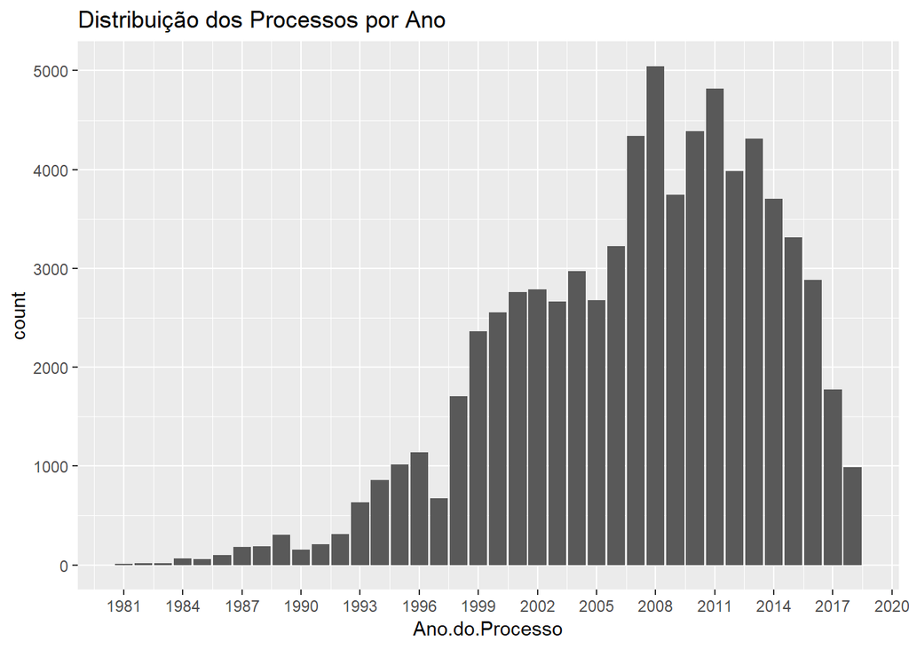

Acima, notamos facilmente que o número de processos vem crescendo desde o ano de 1980, atingindo um pico por volta do ano de 2008. Depois do ano de 2012 podemos ver uma queda mais acentuada do número de processos, que muito provavelmente se deve à crise enfrentanda pelo Brasil nos últimos anos.

Como próxima próxima análise, vamos ver a distribuição dos Hectares

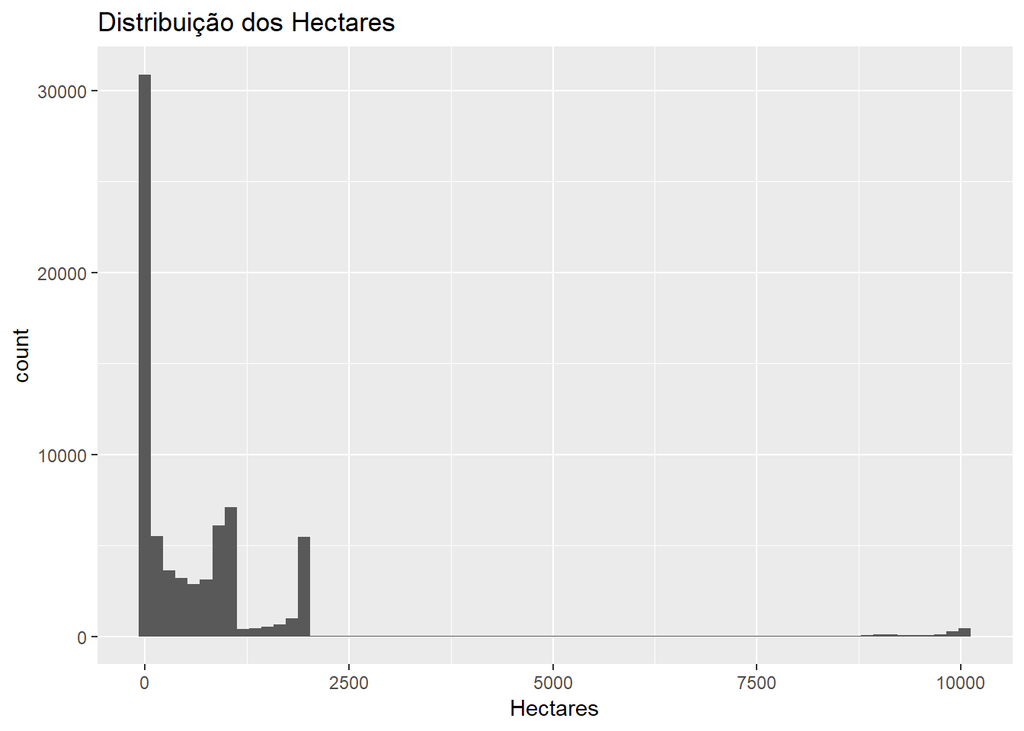

Uma vez que a distribuição dos Hectares é consideravelmente assimétrica à direita (*skewed*), vamos considerar uma transformação logaritmica nas escalas para inspecionar melhor a distribuição dos Hectares.

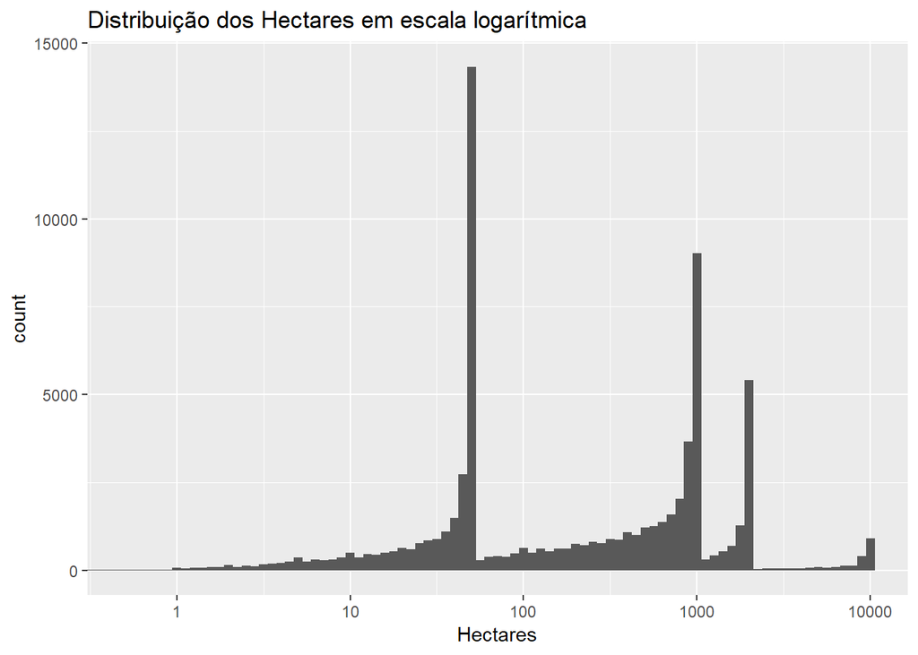

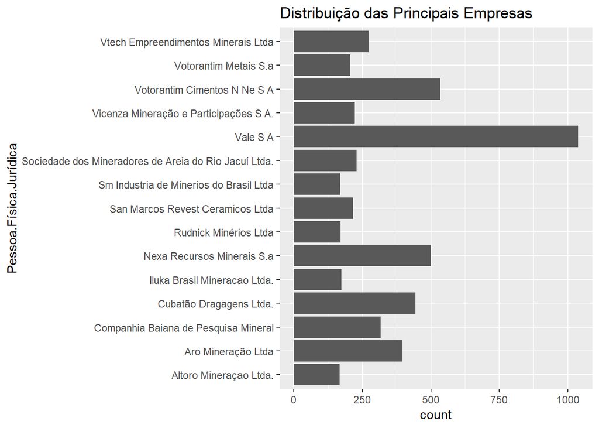

Como poderia ser previsto por um leigo, a empresa Vale S. A. detém o maior número de processos, seguida pela empresa Votorantim Cimentos e Nexa Recursos Minerais.

Seguindo adiante, faremos um histograma para inspecionar a distribuição das fases do projeto de mineração no pagamento da TAH.

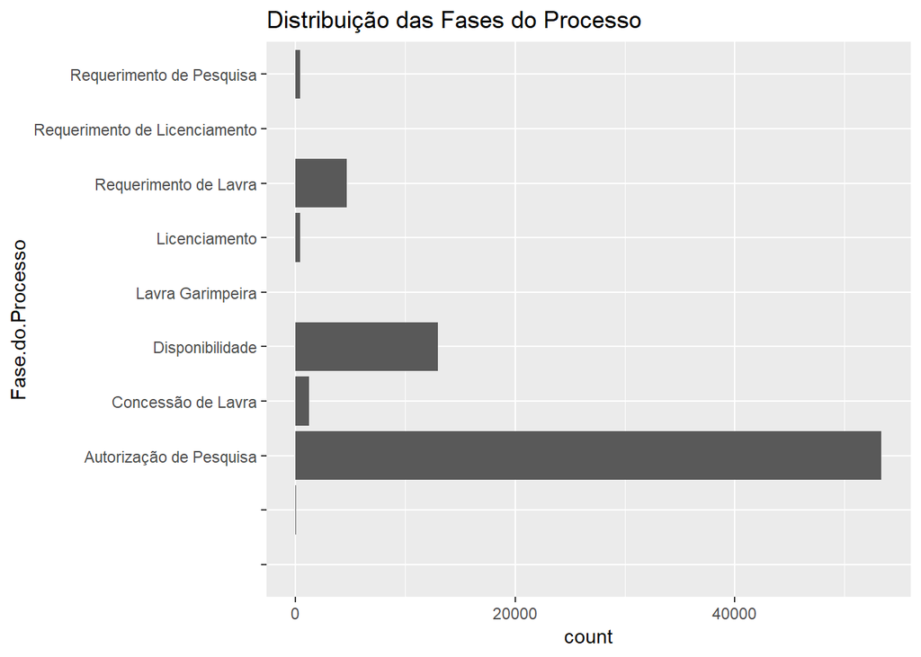

Notamos facilmente a hegemonia da fase de “Autorização de Pesquisa” na distribuição dos processos.

Outro atributo interessante apresentado pelo banco de dados dos processos da TAH é a tal da Superintendência, isto é, qual a participação de cada estado brasileiro na distribuição dos processos.

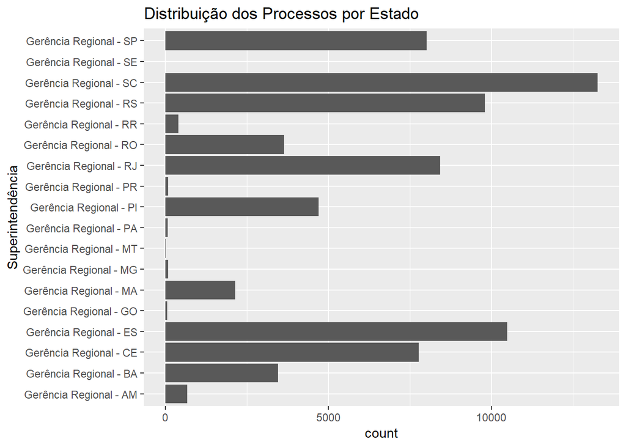

Em termos de **volume**, o estado de SC tem a maior participação. Porém, na seção de gráficos bivariados, veremos que o **valor** arrecadado por estados tem uma distribuição diferente.

Um atributo quantitativo interessante do banco de dados é o referente ao valor cobrado do imposto. Como os valores cobrados têm uma grande dispersão (*overdispersion*), nós plotaremos direto o histograma usando a escala logaritmica.

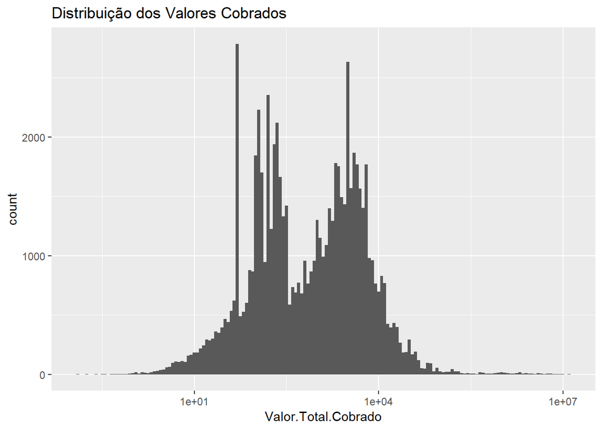

Como último plot desta seção, faremos o histograma do valor pago pelas empresas relativo à TAH. Como os valores pagos também têm uma grande dispersão, nós plotaremos direto o histograma usando a escala logaritmica.

```
## Warning: Transformation introduced infinite values in continuous x-axis
```

```
## Warning: Removed 1063 rows containing non-finite values (stat_bin).
```

[figure not shown]

O *warning* indica a presença de valores zero. Ou seja, alguns processos foram cobrados mas não foram pagos.

## Análise Univariada

### Qual é a estrutura do conjunto de dados?

No conjunto de dados original há cerca de 110 mil observações (processos) contendo 9 atributos, dos quais 5 são quantitativos (“Processo”, “Ano.do.Processo”, “Valor.Total.Cobrado”, “Valor.Pago”, “Hectares”), e 4 são qualitativos (“CPF.CNPJ”, “Pessoa.Física.Jurídica”, “Fase.Processo”, “Superintendência”). Entretanto, no banco de dados original algumas linhas estão mal formatadas, resultando em alguns valores “NaN”. Após a eliminação destes valores espúrios, ficamos com cerca de 73 mil processos.

### Quais são os principais atributos de interesse deste conjunto de dados?

Intiutivamente eu diria que os principais atributos são Hectares, Valores cobrados e valores pagos. O número de Hectares deve estar bem correlacionada com os valores cobrados e pagos.

### Quais outros atributos você acha que podem lhe auxiliar na investigação destes atributos de interesse?

Seria interessante ver como se comportam esses atributos com relação ao ano e empresa. Ademais, também irei utilizar abaixo o atributo “Superintendência” (i.e. o estado) para criar um mapa da arrecadação do TAH.

### Você criou novas variáveis a partir dos atributos existentes no conjunto de dados?

Não.

### Dos atributos investigados, distribuições incomuns foram encontradas? Você aplicou operações nos dados para limpá-los, ajustá-los ou mudar a forma dos dados? Se sim, por quê?

Também fiz algumas operações para limpar os dados de valores do tipo “NaN”.

## Sessão de Gráficos Bivariados

O primeiro plot da sessão bivariada é um gráfico do tipo histograma bidimensional relacionando os hectares e valores pagos e cobrados.

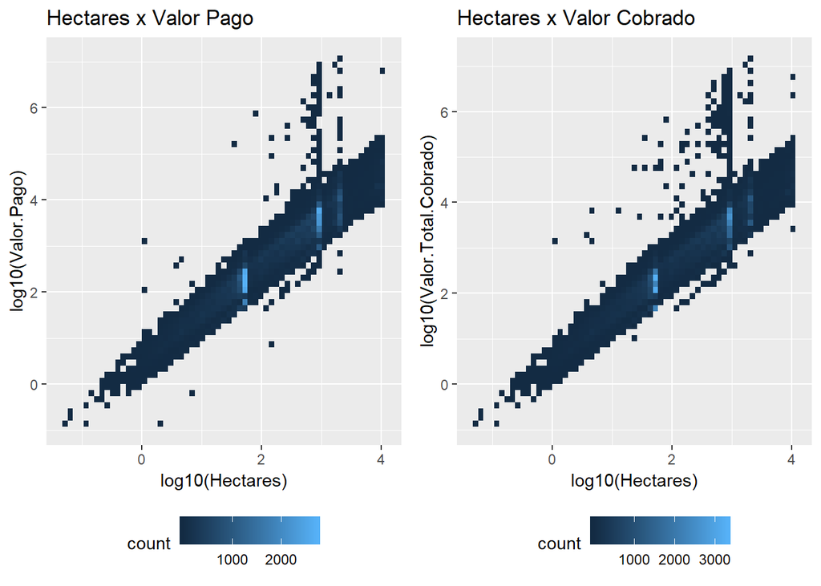

Notamos claramente uma tendência linear nos plots acima, sugerindo uma lei de potências entre o valor pago(cobrado) e o número de hectares da propriedade. Essa tendência ficará mais transparente quando fizermos a análise multivariada. Adicionalmente, podemos ver linhas de acúmulo ao longo alguns valores de hectares já mencionados na seção univariada. É interessante verificar também a presença de valores atípicos quando o número de hectares é mais elevado.

Apesar de os últimos plots indicarem uma grande semelhança entre os valores cobrados e pagos da TAH, para fazer uma comparação mais precisa entre tais valores, vamos plotar um gráfico de densidades, similar ao histograma.

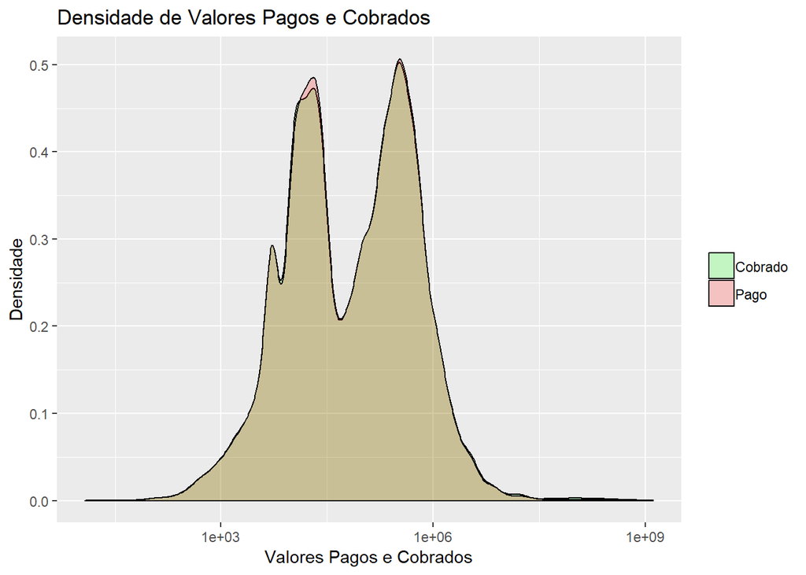

Notamos então que, de fato, há uma discrepância mínima entre os valores cobrados e pagos. Portanto, daqui em diante poderemos assumir que valor pago é mais ou menos igual ao valor cobrado.

Em nosso próximo gráfico bivariado referente à TAH, vamos analisar a quantidade de valores pagos para as principais empresas mineradoras que pagaram a taxa. Para tal tarefa, utilizaremos box plots.

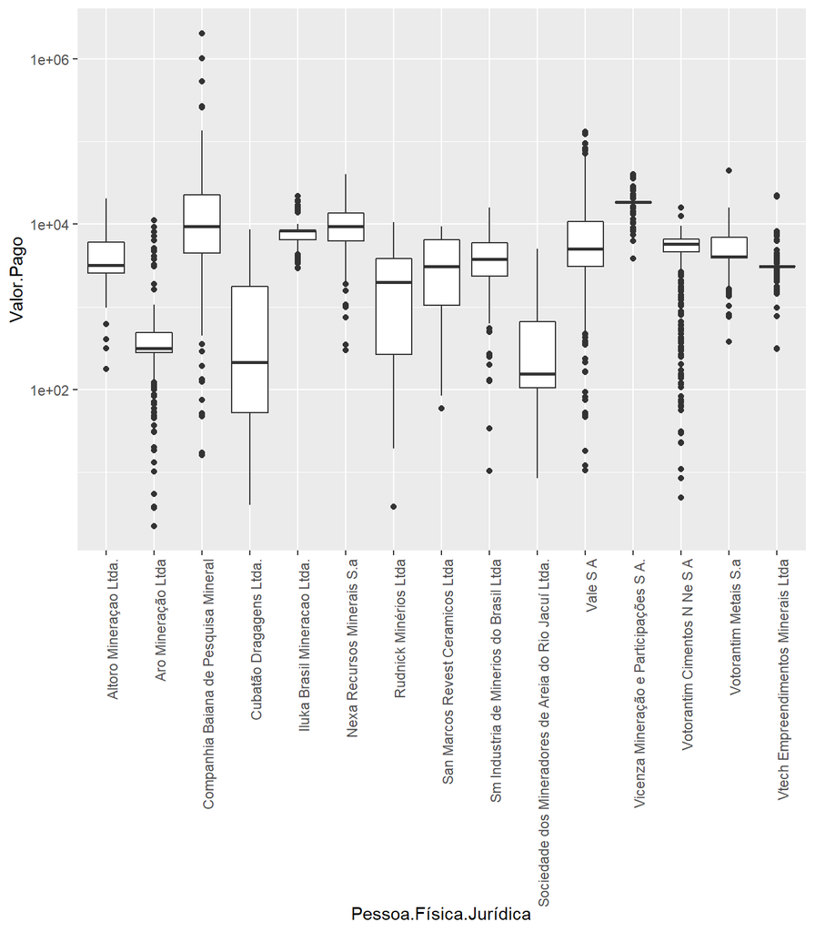

Analogamente, vamos repetir o plot acima, trocando o valor pago pelo valor cobrado.

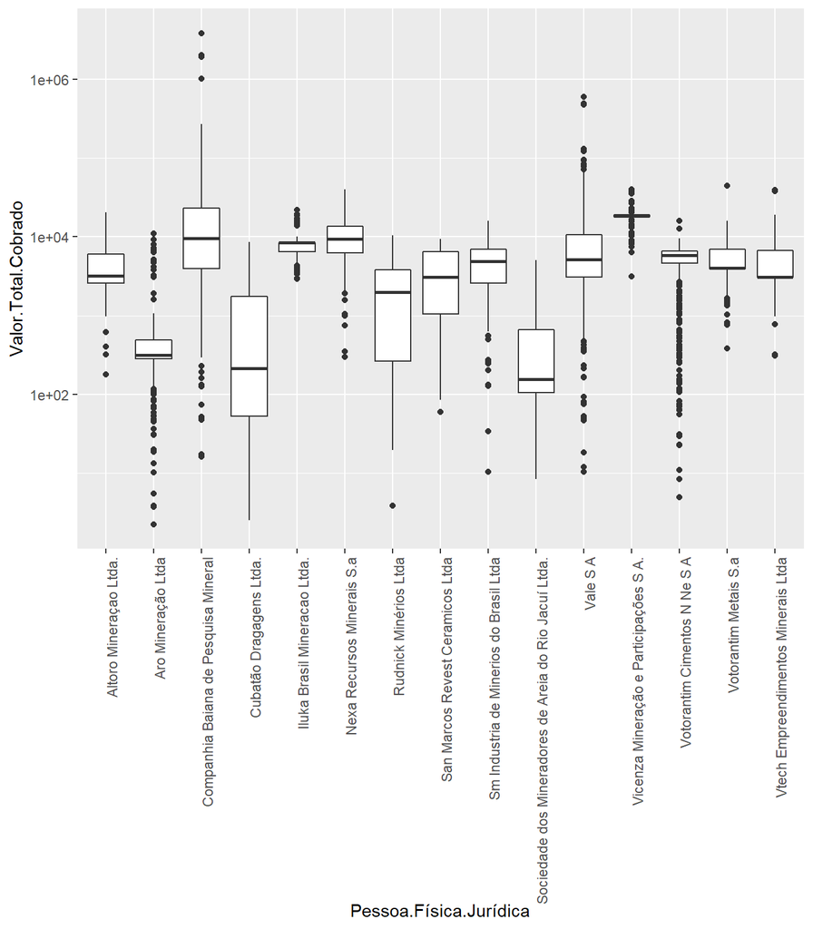

Como esperado, o resultado é semelhante ao box-plot dos valores pagos.

Como próximo passo, vamos confeccionar um plot do tipo box plot comparando o número de hectares dos processos das maiores companhias mineradoras.

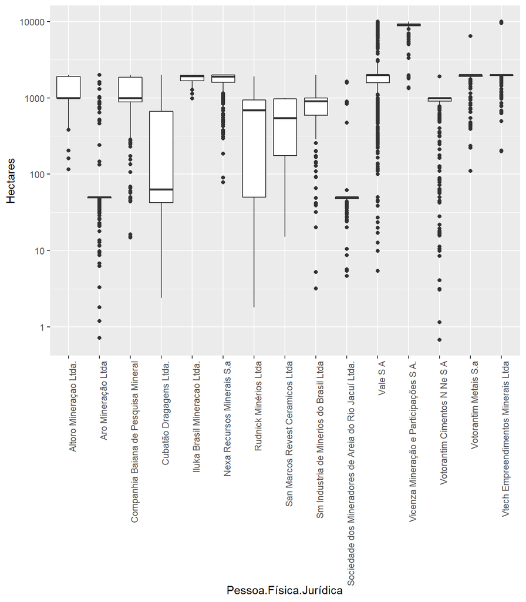

Interessante notar que a maior companhia, i.e. a Vale, possuiu uma grande variedade de tamanhos, desde poucos hectares, até os milhares.

Estando já perto do fim da seção de gráficos bivariados, vamos fazer um histograma em duas dimensões relacionando os valores pagos com o ano do pagamento da TAH.

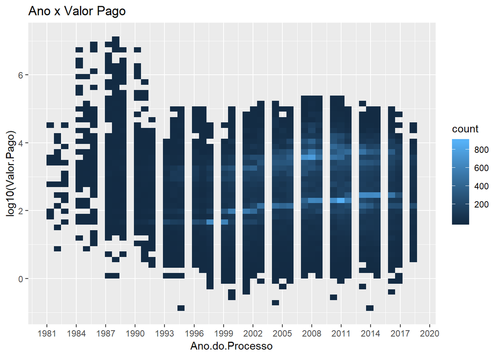

Seguindo o espírito do primeiro gráfico deste trabalho, vemos um grande número de processos sendo pagos por volda de 2008, com um subsequente esmorecimento nos últimos anos, fruto da crise econnômica brasileira.

Como último plot desta seção, vamos calcular o valor acumulado pago por cada estado (superintendência) referente à TAH. Uma vez feito isso, temos o seguinte resultado abaixo:

[figure not shown]

# Análise Bivariada

### Discuta sobre alguns dos relacionamentos observados nesta parte da investigação. Como os atributos de interesse variaram no conjunto de dados?

Dado os atributos de interesse (valor pago, valor cobrado, e hectares), a seção de gráficos bivariados foi muito interessante para descobrir alguns padrões. Primeiramente, descobrimos que o valor pago e o valor cobrado são praticamente iguais, o que indica que o tributo (TAH) foi pago em sua quase totalidade.

Em segundo lugar, notamos um comportamento linear comparando o logarítmo do valor pago (cobrado) com o logarítmo do número de hectares, o que indica que o imposto da TAH é cobrado utilizando alguma lei de potências em função dos hectares da propriedade. Isso ficará mais claro na seção seguinte.

### Você observou algum relacionamento interessante entre os outros atributos (os que não são de interesse)?

Utilizando os dados dos processos segmentados por estados brasileiros, foi possível fazer um mapa que mostra a distribuição do valor total acumulado pago em cada estado relativo à TAH.

### Qual foi o relacionamento mais forte encontrado?

Pode-se dizer, com relativa tranquilidade, que o relacionamento mais forte encontrado foi entre o valor pago (ou cobrado) e o número de hectares.

# Sessão de Gráficos Multivariados

Nesta seção de gráficos multivariados iremos ver como os insights surgem uma vez que mais de dois atributos são utilizados para confeccionar as imagens de visualização dos dados.

Vamos iniciar a análise multivariada plotando o valor pago por hectare estratificado pelas maiores empresas.

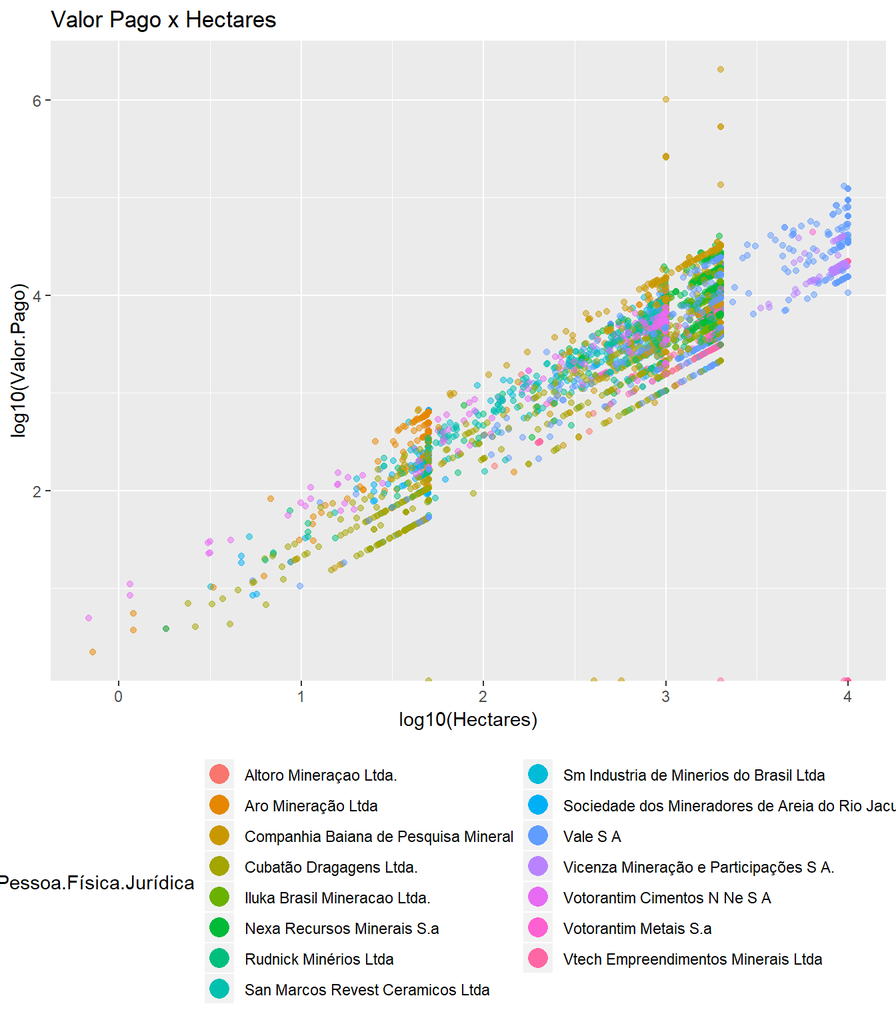

Pelo gráfico acima, podemos ver que os maiores valores de hectares e valores pagos têm predominância da empresa Vale. Podemos ver outros pontos interessantes, por exemplo, a empresa “Aro Mineração Ltda” (bolinha laranja na legenda) tem uma dominância quando o número de hectares é baixo.

De forma análoga, vamos repetir o plot acima, mas agora vamos estratificar o scatter plot por estados brasileiros.

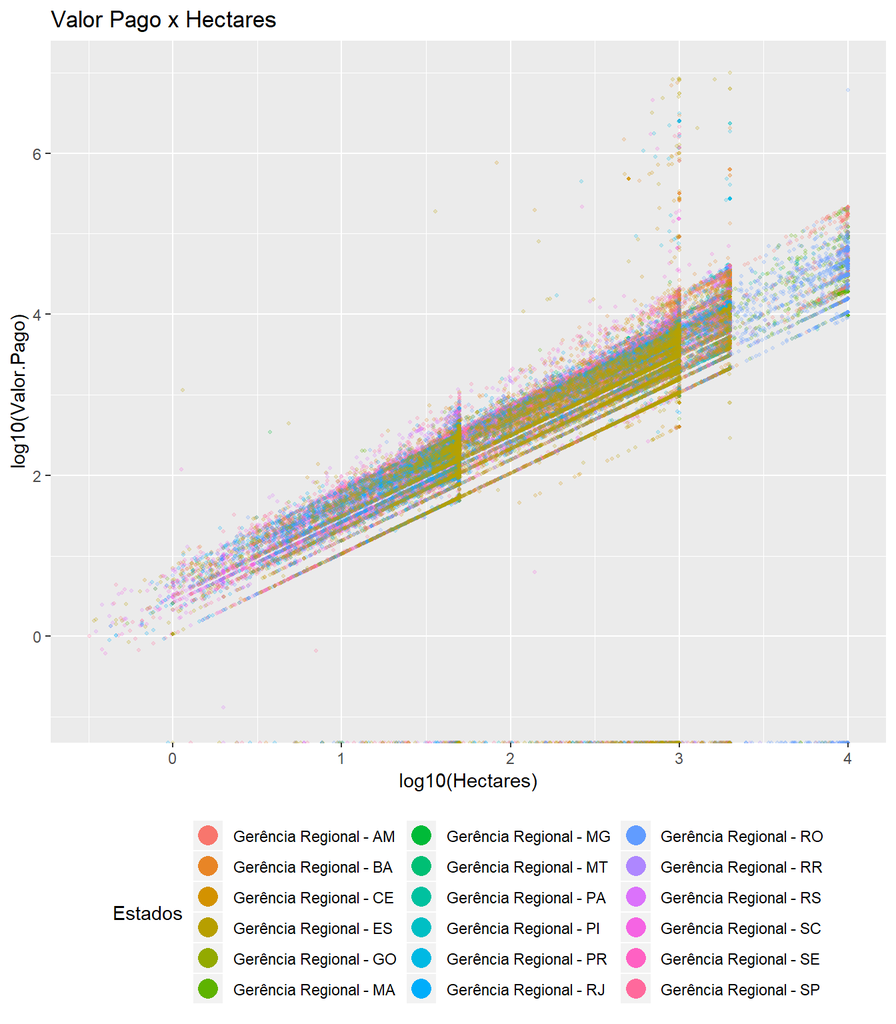

É interessante notar acima que os maiores hectares e, por consequência, os maiores valores pagos, têm forte presença do estado do RJ, com uma participação no topo do estados da Bahia e Ceará. A presença do estado do ES (maior arrecadador da TAH) está mais concentrada no meio do gráfico.

Indo para os estágios finais, vamos ver repetir o gráfico acima mas agora estratificando anualmente o pagamento da taxa por hectares.

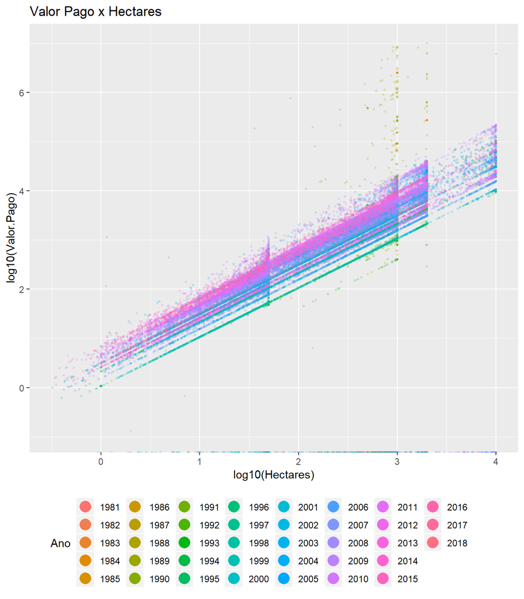

E *voilá*! O gráfico acima mostra claramente a tendência linear da TAH quando estratificamos anualmente. Isto é, para cada ano temos uma reta que descreve o log do valor TAH com o log do número de hectares. Naturalmente, com o passar dos anos o intercepto da reta é deslocado para cima (aumeto da TAH), mas o coeficiente linear parece se manter constante.

# Análise Multivariada

### Discuta sobre os relacionamentos observados nesta parte da investigação. Quais atributos que fortaleceram os demais na observaçõeso das variáveis de interesse?

Em nossas investigações acerca do valor arrecadado e o número de hectares do terreno explorado, foi aventada a hipótese, na sessão de gráficos bivariados, de que o logaritmo dessas duas variáveis tivesse um comportamento linear. Ao estratificarmos essa visualização em termos das demais variáveis, obtivemos uma confirmação (visual) de que de fato, há um comportamento linear entre essas duas variáveis.

Ademais, pudemos observar como fica a distribuição das maiores empresas quando plotamos o valor pago pelo número de hectares.

### Interações surpreendentes e/ou interessantes foram encontradas entre os atributos?

Em nosso último plot, em especial, tivemos um grande insight. Ao plotarmos o log do valor pago em função do log do número de hectares, estratificado pelo ano de pagamento, conseguimos ver que cada ano corresponde a uma reta. Com o passar dos anos, por conta do ajuste da TAH, o intercepto da reta aumenta gradativamente.

# Gráficos Finais e Sumário

### Primeiro Gráfico

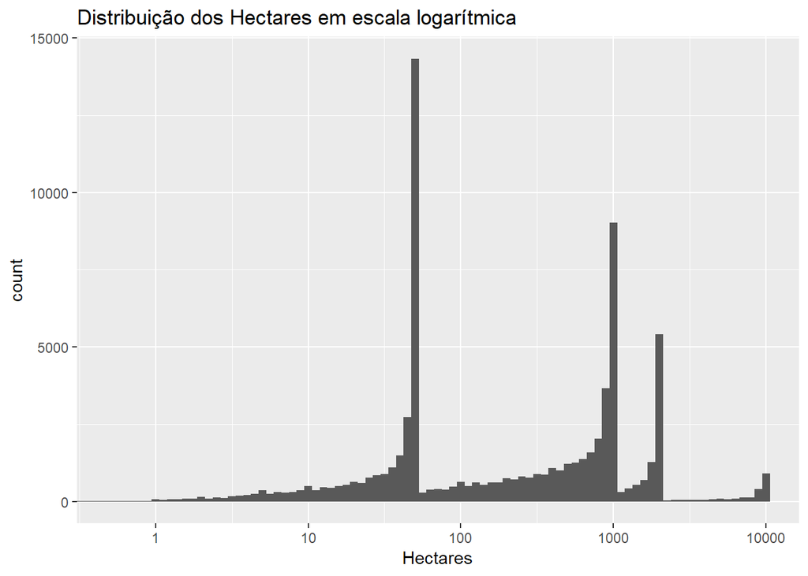

### Segundo Gráfico

[figure not shown]

### Terceiro Gráfico

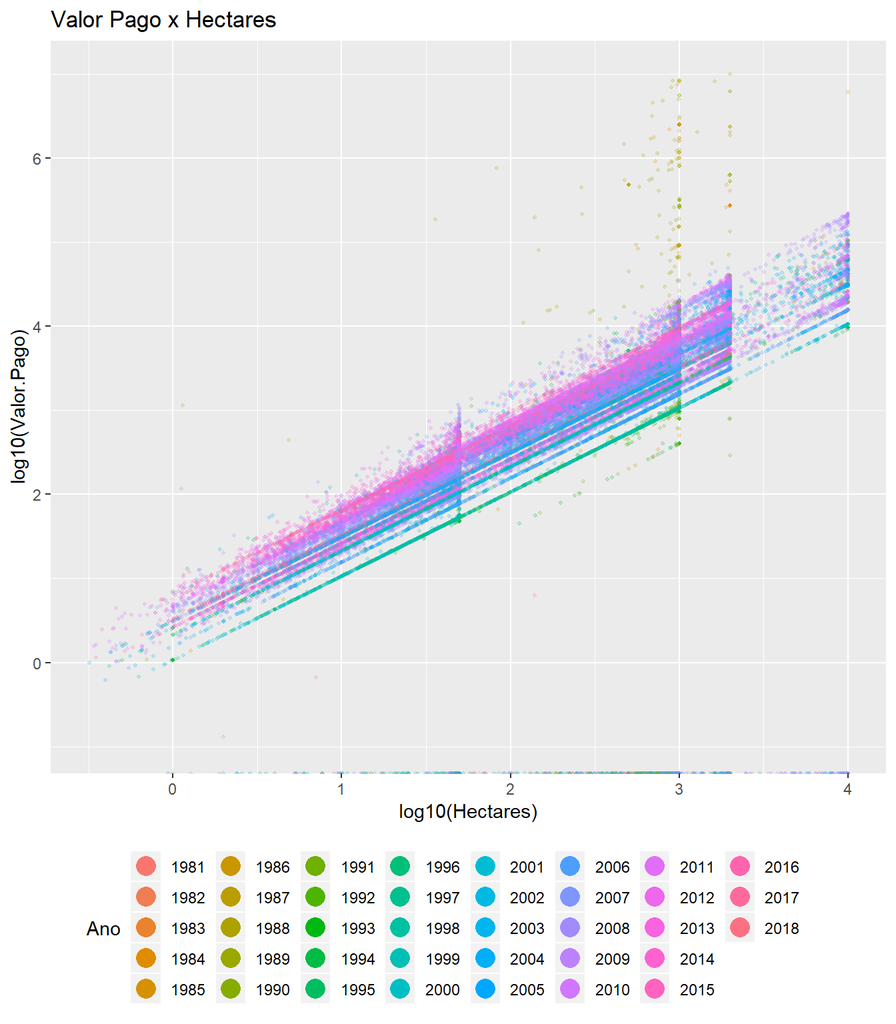

### Descrição do Terceiro Gráfico

O gráfico mostra a tendência linear da TAH quando estratificamos anualmente. Isto é, para cada ano temos uma reta que descreve o log do valor TAH com o log do número de hectares. Naturalmente, com o passar dos anos o intercepto da reta é deslocado para cima (aumeto da TAH), mas o coeficiente linear parece se manter constante.

# Reflexão

Utilizando o banco de dados do governo brasileiro referente ao pagamento da TAH, exploramos e analisamos graficamente os cerca de 73 mil processos.

Na seção da análise univariada, seção essa dedicada à exploração inicial dos dados, já foi possível extrair informações interessantes e relevantes da TAH. Por exemplo, descobrimos um pico de processos feitos por volta do ano de 2008, seguido de uma queda relativamente abrupta oriunda da crise brasileira. Além disso, foi possível ver como é a distribuição dos hectares (vide o “Primeiro Gráfico” logo acima) dos terrenos usados para a exploração mineral do solo brasileiro.

Já na seção de análise bivariada, começamos a ver alguns detalhes mais importantes que não tínhamos visto. Em especial, foi feito um mapa do Brasil que permitiu uma comparação detalhada do arrecadamento da TAH por estado brasileiro. Ademais, nessa seção bivariada também foi possível ver que o valor pago e o valor cobrado foi praticamente o mesmo tirando alguns inadimplentes.

Na última parte deste trabalho, o qual cobre a análise multivariada, foi possível corroborar hipóteses levantadas anteriormente de forma mais precisa, como o fato de que há ume relação linear que descreve o log do valor TAH com o log do número de hectares, conforme mostrado no “Terceiro Gráfico”. Evidentemente, deve ser possível encontrar alguma fórmula para o cálculo da TAH em arquivos jurídicos, mas em minhas buscas online, não consegui encontrar algo simples e direto de cálculo. De qualquer forma,com esta exploração de dados, conseguimos conhecer um pouco mais de uma estrutura tributária do Brasil.